# Reproducible Research: Peer Assessment 1

Julia Borman

June, 2016

## About

This assignment makes use of data from a personal activity monitoring device. This device collects data at 5 minute intervals through out the day. The data consists of two months of data from an anonymous individual collected during the months of October and November, 2012 and include the number of steps taken in 5 minute intervals each day.

Assignment desciption, markdown template, relevant README files and data are available on the [GitHub repository created for this assignment](https://github.com/rdpeng/RepData_PeerAssessment1).

## Data

The data for this assignment can also be downloaded from the course web site:

- Dataset: [Activity monitoring data](https://d396qusza40orc.cloudfront.net/repdata%2Fdata%2Factivity.zip)

The variables included in this dataset are:

- **steps**: Number of steps taking in a 5-minute interval (missing values are coded as `NA`)
- **date**: The date on which the measurement was taken in YYYY-MM-DD format
- **interval**: Identifier for the 5-minute interval in which measurement was taken

## Loading and preprocessing the data

First, we need to load the data and then process/transform these data into a format suitable for the analysis below.

#### Bring in data

Load data into dataframe `data`

```r
if(!file.exists('activity.csv')){
   unzip('activity.zip')
}
data<-read.csv("activity.csv", stringsAsFactors = F)
data$date<-as.Date(data$date)
```

## What is mean total number of steps taken per day?

For this part of the assignment, we ignore the missing values in the dataset.

#### Calculate the total number of steps taken per day

```r
stepsbyday<-unlist(lapply(split(data, data$date), function(x){sum(x$steps, na.rm=T)}))
```

#### Make a histogram of the total number of steps taken each day

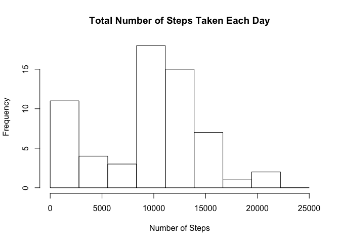

```r
hist(stepsbyday, main='Total Number of Steps Taken Each Day', xlab='Number of Steps', breaks=seq(0, 25000, length.out = 10))
```

#### Calculate and report the mean and median of the total number of steps taken per day

```r
mean.stepsbyday<-mean(stepsbyday)
median.stepsbyday<-median(stepsbyday)
```

The mean total number of steps taken per day is 9354.23, and the median of total steps per day is 10395.

## What is the average daily activity pattern?

We look at the average number of steps taken for each 5 minute interval over all days and see which contains the maximum number of steps.

#### Time series plot of the 5-minute interval and the average number of steps taken, averaged across all days.

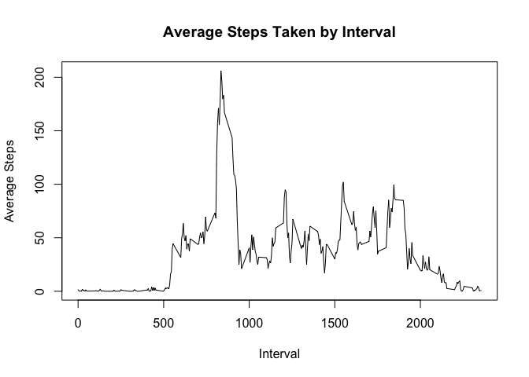

```r
avg.steps.byinterval<-unlist(lapply(split(data, data$interval), function(x){mean(x$steps, na.rm=T)}))
plot(x=unique(data$interval), y=avg.steps.byinterval, main='Average Steps Taken by Interval', type='l', xlab='Interval', ylab='Average Steps')
```

#### Which 5-minute interval, on average across all the days in the dataset, contains the maximum number of steps?

```r
indx<-which(avg.steps.byinterval==max(avg.steps.byinterval))
int<-names(avg.steps.byinterval)[indx]
val<-avg.steps.byinterval[indx]
```

The maximum average steps by interval occurs in the 835 interval, with an average of 206.1698113 steps.